# CS5801 Coursework Template Proforma

2144810

09 Enero, 2022

# 0. Instructions

*1. Remove the (italicised) guidance text but keep the section headings.*  
*2. Add as many chunks of R code as required.*  
*3. Add descriptions of your analysis plans and explanations of your code and findings. Please be detailed and where you have made choices explain the rationale for them.*  
*4. Write your report using RMarkdown. For guidance see a [helpful blog](https://www.dataquest.io/blog/r-markdown-guide-cheatsheet/#tve-jump-17333da0719) or use the R Markdown cheatsheet which can be accessed from within RStudio by selecting `Help > Cheatsheets > R Markdown Cheat Sheet`.*  
*5. Your report should be clearly and professionally presented with appropriate use of cited external sources. (5 marks)*  
*6. It should also be easy to understand, with well-documented code following the principles of literate programming. (5 marks)*

```r
# Add code here to load any required libraries with `library()`.
# We suggest you use `install.package()` for any required packages externally to this document
# since installation only need be done once.
library(corrplot)
library(ggpubr)
options(scipen = 999)
```

# 1. Organise and clean the data

## 1.1 Subset the data into the specific dataset allocated

*A description of the data set provided, its contents and which subset you should select is documented in the assessment brief at ???.pdf*  
*Use R code to correctly select the subset of data allocated. (5 marks)*

```r
# Assign your student id into the variable SID, for example:
SID <- 2144810                  # This is an example, replace 2101234 with your actual ID
SIDoffset <- (SID %% 25) + 1    # Your SID mod 25 + 1

load("CS5801_football_analysis.Rda")
# Now subset the football data set
# Pick every 25th observation starting from your offset
# Put into your data frame named mydf (you can rename it)
mydf <- football.analysis[seq(from=SIDoffset,to=nrow(football.analysis),by=25),]
write.csv(mydf, "data.csv")
```

## 1.2 Data quality analysis

*Provide a description of a comprehensive plan to assess the quality of the data, and document your findings. Include all variables/columns (5 marks) from the data set and provide a full implementation (5 marks). NB even if no data quality issues are identified you should still check and report.*

Here is my following plan to check the quality of the data for each column:

1. `sofifa_id`: First, it must be checked if the column is a string. Then it must be checked if each value is unique since it is an ID. It must be checked if missing values (NA) exist.
2. For columns `wage_eur`, `age`, `height_cm` and `weight_kg`, it must be checked that the columns are numerical. Then it must be checked that values are not below 0. It also must be checked for outliers and if they are reasonable or not. It must be checked if missing values (NA) exist.
3. For columns `potential`, `pace`, `shooting`,`passing`, `dribbling`, `defending`, `physic`, `power_strength` and `power_long_shots`, it must be checked that the column is numerical. Then it must be checked that the maximum value is not above 100 and that the minimum value is not below 0. It must be checked if missing values (NA) exist.
4. `club_name`: First, it must be checked that the column is a string. This column won’t be used for analysis so not further studying will be done.
5. `preferred_foot`: First, it must be checked that the column is categorical (factor). This column must be constraint to two unique values: `Right` and `Left`. It exist the possibility that values like `left` or `LEft` could be encountered and if they do, they need to be changed to the 2 unique values. It must be checked if missing values (NA) exist.
6. `high.wage.ind`: First, it must be checked that the column is categorical (factor). This column must be constraint to two unique values: `1` and `0`. It must be checked if missing values (NA) exist. It also must be checked that it has a value of `1` if weekly wage is above 8000 and `0` otherwise.

**Note:** a) NA refers to Not Available. b) There are many methods for calculating outliers. However, for this lab, 3 will be used. The first is by using a boxplot. Where points are visualized, outliers exist. The second method is by using the standard deviation (std). Values that are beyond 3 stds from the mean are considered outliers. The final method is using interquartile range (IQR). Values that are beyond quartile 3 plus 1.5 times the IQR and values that are below quartile 1 minus 1.5 times the IQR are considered outliers.

### Checking for quality issues:

1. Checking data type of each column:

```r
str(mydf)
```

```
## 'data.frame':    514 obs. of  17 variables:
##  $ sofifa_id       : int  155862 218667 189513 146536 212194 186345 208574 176635 210665 179846 ...
##  $ potential       : int  89 88 85 84 88 83 83 82 82 81 ...
##  $ wage_eur        : num  300000 230000 59000 43000 75000 71000 45000 100000 65000 87000 ...
##  $ age             : int  34 25 31 34 24 29 27 31 28 33 ...
##  $ height_cm       : int  184 173 182 172 185 173 184 180 188 189 ...
##  $ weight_kg       : int  82 64 74 60 83 71 82 71 87 90 ...
##  $ club_name       : chr  "Real Madrid CF" "Manchester City" "Villarreal CF" "Sevilla FC" ...
##  $ preferred_foot  : chr  "Right" "Left" "Right" "Right" ...
##  $ pace            : int  71 81 50 87 81 73 88 64 66 45 ...
##  $ shooting        : int  70 77 83 69 78 60 76 69 66 74 ...
##  $ passing         : int  76 83 90 79 82 81 79 85 73 77 ...
##  $ dribbling       : int  73 92 81 83 87 77 83 83 72 77 ...
##  $ defending       : int  88 51 71 80 51 79 68 24 81 79 ...
##  $ physic          : int  85 67 69 58 66 72 80 55 80 78 ...
##  $ power_strength  : int  85 54 70 39 71 64 77 56 79 85 ...
##  $ power_long_shots: int  64 76 88 70 80 70 78 67 69 78 ...
##  $ high.wage.ind   : int  1 1 1 1 1 1 1 1 1 1 ...
```

- `power_long_shots`, `power_strength`, `physic`, `defending`, `dribbling`, `passing`, `shooting`, `pace` and `potential` have the right data type. They are integers (numerical).
- `high.wage.ind` is integer (numerical) and therefore it needs to be changed to categorical (factor).
- `preferred_foot` is a string (character) and needs to be changed to categorical (factor).
- `sofifa_id` is a integer (numerical) and needs to be changed to string (character).
- `wage_eur` is numerical therefore it is correct.
- `age`, `height_cm`, `weight_kg` are integer (numerical) and therefore they are correct.
- `club_name` is a string (character) and therefore it is correct.
2. Checking for missing values (NA) for each column:

```r
# df_col_names is a list of all the column names of our dataframe.
df_col_names <- c(colnames(mydf))
# iteration over each column to find missing values.
for (col_name in df_col_names){
  message = paste("Column", col_name, "has", sum(is.na(mydf$col_name)), "missing values (NA)")
  print(message)
}
```

```
## [1] "Column sofifa_id has 0 missing values (NA)"
## [1] "Column potential has 0 missing values (NA)"
## [1] "Column wage_eur has 0 missing values (NA)"
## [1] "Column age has 0 missing values (NA)"
## [1] "Column height_cm has 0 missing values (NA)"
## [1] "Column weight_kg has 0 missing values (NA)"
## [1] "Column club_name has 0 missing values (NA)"
## [1] "Column preferred_foot has 0 missing values (NA)"
## [1] "Column pace has 0 missing values (NA)"
## [1] "Column shooting has 0 missing values (NA)"
## [1] "Column passing has 0 missing values (NA)"
## [1] "Column dribbling has 0 missing values (NA)"
## [1] "Column defending has 0 missing values (NA)"
## [1] "Column physic has 0 missing values (NA)"
## [1] "Column power_strength has 0 missing values (NA)"
## [1] "Column power_long_shots has 0 missing values (NA)"
## [1] "Column high.wage.ind has 0 missing values (NA)"
```

No missing values were found in any column.

3. Check maximum and minimum values for numerical columns:

```r
summary(mydf)
```

```
##    sofifa_id        potential        wage_eur           age
##  Min.   :143809   Min.   :54.00   Min.   :     4   Min.   :16.00
##  1st Qu.:211561   1st Qu.:67.00   1st Qu.:  1000   1st Qu.:22.00
##  Median :232602   Median :72.00   Median :  3000   Median :25.00
##  Mean   :227354   Mean   :71.67   Mean   : 10821   Mean   :25.22
##  3rd Qu.:247061   3rd Qu.:76.00   3rd Qu.: 10000   3rd Qu.:28.00
##  Max.   :258923   Max.   :89.00   Max.   :300000   Max.   :77.00
##    height_cm       weight_kg       club_name         preferred_foot
##  Min.   :160.0   Min.   : 58.00   Length:514         Length:514
##  1st Qu.:175.0   1st Qu.: 70.00   Class :character   Class :character
##  Median :180.0   Median : 75.00   Mode  :character   Mode  :character
##  Mean   :180.1   Mean   : 74.54
##  3rd Qu.:185.0   3rd Qu.: 79.00
##  Max.   :220.0   Max.   :188.00
##       pace           shooting        passing        dribbling
##  Min.   :-66.00   Min.   :21.00   Min.   :26.00   Min.   :-66.0
##  1st Qu.: 62.00   1st Qu.:42.00   1st Qu.:51.00   1st Qu.: 57.0
##  Median : 69.00   Median :55.00   Median :58.00   Median : 64.0
##  Mean   : 68.13   Mean   :53.04   Mean   :57.81   Mean   : 62.8
##  3rd Qu.: 76.00   3rd Qu.:65.00   3rd Qu.:65.00   3rd Qu.: 70.0
##  Max.   : 94.00   Max.   :83.00   Max.   :90.00   Max.   : 92.0
##    defending         physic      power_strength  power_long_shots
##  Min.   :18.00   Min.   :35.00   Min.   :29.00   Min.   :16.00
##  1st Qu.:36.00   1st Qu.:58.00   1st Qu.:57.00   1st Qu.:40.00
##  Median :57.00   Median :66.00   Median :67.00   Median :54.00
##  Mean   :51.53   Mean   :64.61   Mean   :65.31   Mean   :51.83
##  3rd Qu.:65.00   3rd Qu.:72.00   3rd Qu.:75.00   3rd Qu.:64.00
##  Max.   :88.00   Max.   :85.00   Max.   :93.00   Max.   :88.00
##  high.wage.ind
##  Min.   :0.0000
##  1st Qu.:0.0000
##  Median :0.0000
##  Mean   :0.2899
##  3rd Qu.:1.0000
##  Max.   :1.0000
```

Checking for low values in the `wage_eur` column.

```r
mydf[mydf["wage_eur"]<500,]
```

|  | sofifa_id | potential | wage_eur | age | height_cm | weight_kg | club_name | preferred_foot | pace | shooting | passing | dribbling | defending | physic | power_strength | power_long_shots | high.wage.ind |
| --- | --- | --- | --- | --- | --- | --- | --- | --- | --- | --- | --- | --- | --- | --- | --- | --- | --- |
| 5111 | 222993 | 68 | 4.0001 | 30 | 177 | 68 | Cerezo Osaka | Right | 75 | 65 | 61 | 69 | 25 | 61 | 64 | 65 | 0 |

- There is one player which weekly wage in euros is 4. This player belongs to a team in Japan (Cerezo Osaka). This is consider an error since the minimum weekly wage for someone in Japan is around 340 euros. [1]
- Columns `pace` and `dribbling` need further investigation since their minimum value is -66.

```r
mydf[mydf["pace"] < 0,]
```

|  | sofifa_id | potential | wage_eur | age | height_cm | weight_kg | club_name | preferred_foot | pace | shooting | passing | dribbling | defending | physic | power_strength | power_long_shots | high.wage.ind |
| --- | --- | --- | --- | --- | --- | --- | --- | --- | --- | --- | --- | --- | --- | --- | --- | --- | --- |
| 6011 | 237742 | 70 | 2000 | 25 | 179 | 80 | Hokkaido Consadole Sapporo | Right | -66 | 53 | 65 | 67 | 61 | 75 | 80 | 50 | 0 |

Column `pace` has one row which value is -66 which is below 0.

```r
mydf[mydf["dribbling"] < 0,]
```

|  | sofifa_id | potential | wage_eur | age | height_cm | weight_kg | club_name | preferred_foot | pace | shooting | passing | dribbling | defending | physic | power_strength | power_long_shots | high.wage.ind |
| --- | --- | --- | --- | --- | --- | --- | --- | --- | --- | --- | --- | --- | --- | --- | --- | --- | --- |
| 7561 | 248011 | 73 | 3000 | 22 | 180 | 76 | Sepsi OSK Sf. Gheorghe | Right | 68 | 56 | 61 | -66 | 45 | 67 | 67 | 55 | 0 |

Column `dribbling` has one row which value is -66 which is below 0.

4. Looking for outliers in columns `wage_eur`, `age`, `height_cm` and `weight_kg`.

Outliers using IQR method:

```r
c_col <- c("wage_eur", "age", "height_cm", "weight_kg")

# Outliers using IQR
for (col in c_col){
  # calculating iqr method
  iqr <- IQR(mydf[, col])
  # calculatating q1 and q3
  quant <- quantile(mydf[, col], c(0.25, 0.75))
  # numbers below min limit will be considered outliers
  min_limit <- quant[1] - 1.5*iqr
  # numbers above max limit will be considered outliers
  max_limit <- quant[2] + 1.5*iqr
  print(mydf[mydf[col] > max_limit, ])
  print(mydf[mydf[col] < min_limit, ])
}
```

```
##      sofifa_id potential wage_eur age height_cm weight_kg
## 11      155862        89   300000  34       184        82
## 36      218667        88   230000  25       173        64
## 61      189513        85    59000  31       182        74
## 86      146536        84    43000  34       172        60
## 111     212194        88    75000  24       185        83
## 136     186345        83    71000  29       173        71
## 161     208574        83    45000  27       184        82
## 186     176635        82   100000  31       180        71
## 211     210665        82    65000  28       188        87
## 236     179846        81    87000  33       189        90
## 261     204884        84   115000  25       185        85
## 286     225850        85    69000  24       189        80
## 311     159145        80    53000  34       184        77
## 336     189805        80    38000  29       188        86
```

[output cut: 228 more lines]

Outliers using Standard Deviation method:

```r
# Outliers using sd
for (col in c_col){
  sd_col <- 3*sd(mydf[, col])
  mean_col <- mean(mydf[, col])
  min_limit <- mean_col - sd_col
  max_limit <- mean_col + sd_col
  print(mydf[mydf[col] > max_limit, ])
  print(mydf[mydf[col] < min_limit, ])
}
```

```
##     sofifa_id potential wage_eur age height_cm weight_kg
## 11     155862        89   300000  34       184        82
## 36     218667        88   230000  25       173        64
## 186    176635        82   100000  31       180        71
## 236    179846        81    87000  33       189        90
## 261    204884        84   115000  25       185        85
## 361    202750        80    84000  29       195        97
## 436    178509        79    95000  33       193        91
##                   club_name preferred_foot pace shooting passing dribbling
## 11           Real Madrid CF          Right   71       70      76        73
## 36          Manchester City           Left   81       77      83        92
## 186                 Arsenal           Left   64       69      85        83
## 236                Juventus          Right   45       74      77        77
## 261         Manchester City           Left   80       54      77        77
## 361 Wolverhampton Wanderers          Right   62       36      64        64
```

[output cut: 51 more lines]

- The first outlier found was a player which age is 77. This number I believe is incorrect because it is too old to be a football player at professional football. [2]
- The second outlier found was a player which height is 220cm. This number I believe is incorrect. [3]
- The third outlier found was a player which weight is 188kg. This number is to high to be correct. [4]
5. Checking for duplicates on the `sofifa_id`

```r
# Check for duplicated values
num_duplic = sum(duplicated(mydf$sofifa_id))
message = paste("There are", num_duplic, "duplicated values")
print(message)
```

```
## [1] "There are 1 duplicated values"
```

```r
mydf[duplicated(mydf$sofifa_id),]
```

|  | sofifa_id | potential | wage_eur | age | height_cm | weight_kg | club_name | preferred_foot | pace | shooting | passing | dribbling | defending | physic | power_strength | power_long_shots | high.wage.ind |
| --- | --- | --- | --- | --- | --- | --- | --- | --- | --- | --- | --- | --- | --- | --- | --- | --- | --- |
| 4011 | 230400 | 70 | 8000 | 31 | 185 | 84 | Atlético Tucumán | Right | 68 | 69 | 68 | 71 | 59 | 74 | 70 | 68 | 0 |

There is 1 duplicated row on the `sofida_id` column.

6. Checking for unique values on the `high.wage.ind` and `preferred_foot` columns.

```r
table(mydf$"high.wage.ind")
```

```
##
##   0   1
## 365 149
```

There are 365 values for “0” and 149 values for “1”

```r
table(mydf$"preferred_foot")
```

```
##
##  Left right Right
##   121     1   392
```

Values must be constrained to 2 unique values: “Left”, “Right”, however, 1 “right” value was found and it must be changed. There are 121 values for “Left” and 392 values for “Right”.

7. Checking for binary value to be correct. It should be “1” if weekly wage is above 8000 and “0” otherwise.

```r
a <- mydf[mydf["wage_eur"] > 8000,]
sum(mydf[mydf["wage_eur"] > 8000,]["high.wage.ind"])
```

```
## [1] 149
```

```r
sum(mydf[mydf["wage_eur"] <= 8000,]["high.wage.ind"])
```

```
## [1] 0
```

All values above 8000 are “1” and “0” otherwise. Not mistakes were found.

## 1.3 Data cleaning

*Explain any data quality issues found in 1.2 (5 marks), justify and document the responses made (if any) (5 marks).*

Data quality issues found:

### Data Cleaning Implementation:

```r
df_clean <- data.frame(mydf)
```

1. Fixing the “right” value to “Right”

```r
df_clean[df_clean["preferred_foot"]=="right",]["preferred_foot"] <- "Right"
table(df_clean$"preferred_foot")
```

```
##
##  Left Right
##   121   393
```

2. Converting `sofifa_id`, `preferred_foot` and `high.wage.ind` to their factor data type.

```r
df_clean$"sofifa_id" <- as.character(df_clean$"sofifa_id")
df_clean$"preferred_foot" <- as.factor(df_clean$"preferred_foot")
df_clean$"high.wage.ind" <- as.factor(df_clean$"high.wage.ind")
str(df_clean)
```

```
## 'data.frame':    514 obs. of  17 variables:
##  $ sofifa_id       : chr  "155862" "218667" "189513" "146536" ...
##  $ potential       : int  89 88 85 84 88 83 83 82 82 81 ...
##  $ wage_eur        : num  300000 230000 59000 43000 75000 71000 45000 100000 65000 87000 ...
##  $ age             : int  34 25 31 34 24 29 27 31 28 33 ...
##  $ height_cm       : int  184 173 182 172 185 173 184 180 188 189 ...
##  $ weight_kg       : int  82 64 74 60 83 71 82 71 87 90 ...
##  $ club_name       : chr  "Real Madrid CF" "Manchester City" "Villarreal CF" "Sevilla FC" ...
##  $ preferred_foot  : Factor w/ 2 levels "Left","Right": 2 1 2 2 2 2 1 1 1 2 ...
##  $ pace            : int  71 81 50 87 81 73 88 64 66 45 ...
##  $ shooting        : int  70 77 83 69 78 60 76 69 66 74 ...
##  $ passing         : int  76 83 90 79 82 81 79 85 73 77 ...
##  $ dribbling       : int  73 92 81 83 87 77 83 83 72 77 ...
##  $ defending       : int  88 51 71 80 51 79 68 24 81 79 ...
##  $ physic          : int  85 67 69 58 66 72 80 55 80 78 ...
##  $ power_strength  : int  85 54 70 39 71 64 77 56 79 85 ...
##  $ power_long_shots: int  64 76 88 70 80 70 78 67 69 78 ...
##  $ high.wage.ind   : Factor w/ 2 levels "0","1": 2 2 2 2 2 2 2 2 2 2 ...
```

Now, all data types are correct.

We will try to use correlation to find the most suitable columns to be used in a regression model to fix the incorrect numbers.

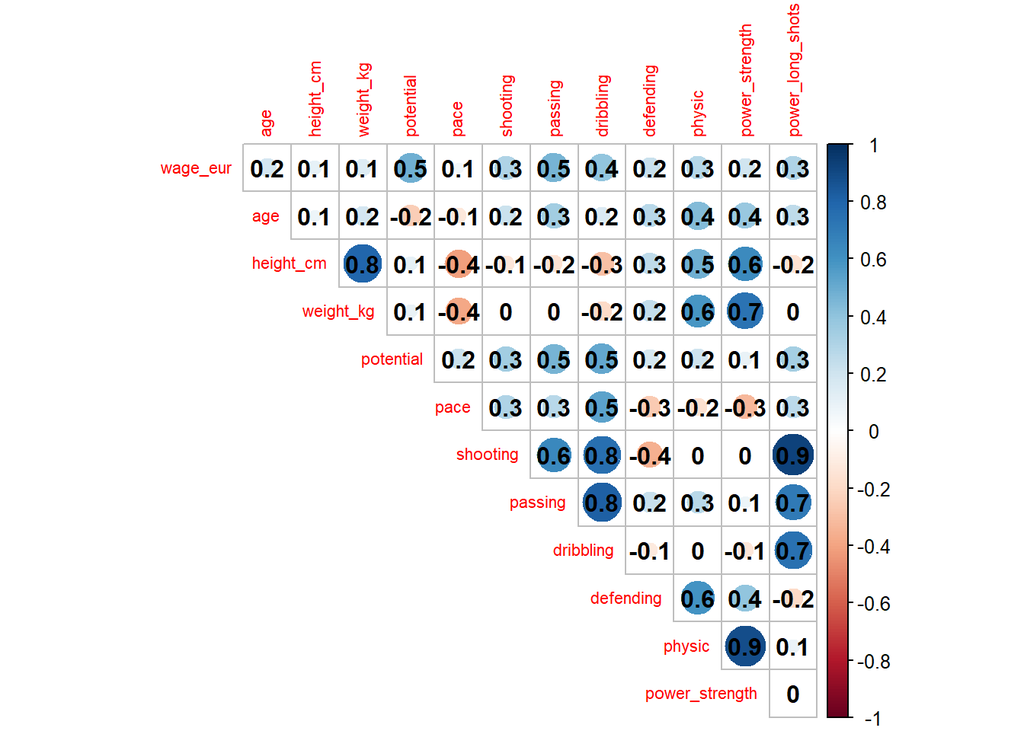

```r
num_col <- c("wage_eur",
             "age",
             "height_cm",
             "weight_kg",
             "potential",
             "pace",
             "shooting",
             "passing",
             "dribbling",
             "defending",
             "physic",
             "power_strength",
             "power_long_shots")

df_cor <- subset(df_clean, select=num_col)
df_cor <- df_cor[df_cor$"pace" > 0 & df_cor$"dribbling" > 0 & df_cor$"weight_kg" != 188 & df_cor$"height_cm" != 220, ]
cor_matrix <- cor(df_cor)
corrplot(cor_matrix, diag=F, type="upper", insig="p-value", number.digits=1, addCoef.col="black", tl.cex=0.7)
```

Since the `pace` value is not highly correlated with any value, the incorrect value will be replaced by the mean of the `pace` column. The column `dribbling` is highly correlated with the columns `passing` and `shooting`. Therefore, any of both values can be used to correct the negative values. The relation between `passing` and `dribbling` will be used to correct the negative values.

3. Correcting the value -66 in the `pace` column with the mean. The mean value was calculated without the -66 value. Also, correcting the value -66 in the `dribbling` column using the `passing` column since it is the most correlated to it.

```r
mean_pace <- mean(df_clean[df_clean$"pace" != -66,]$"pace")
df_clean[df_clean$"pace" == -66,]["pace"] <- mean_pace
```

Checking if changes in the `pace` column were made.

```r
df_clean[df_clean$"pace" < 0,]
```

| sofifa_id | potential | wage_eur | age | height_cm | weight_kg | club_name | preferred_foot | pace | shooting | passing | dribbling | defending | physic | power_strength | power_long_shots | high.wage.ind |
| --- | --- | --- | --- | --- | --- | --- | --- | --- | --- | --- | --- | --- | --- | --- | --- | --- |

The column `pace` now does not have negative values.

Since `dribbling` is highly correlated with `passing`, I will build a regression model with `dribbling` as my dependent variable and `passing` as my independent variable to fix the -66 value.

```r
model_dribbling <- lm(dribbling~passing, data=df_clean)
summary(model_dribbling)
```

```
##
## Call:
## lm(formula = dribbling ~ passing, data = df_clean)
##
## Residuals:
##      Min       1Q   Median       3Q      Max
## -131.300   -3.257    0.265    3.864   20.049
##
## Coefficients:
##             Estimate Std. Error t value            Pr(>|t|)
## (Intercept) 17.55846    2.05531   8.543 <0.0000000000000002 ***
## passing      0.78265    0.03501  22.355 <0.0000000000000002 ***
## ---
## Signif. codes:  0 '***' 0.001 '**' 0.01 '*' 0.05 '.' 0.1 ' ' 1
##
## Residual standard error: 8.139 on 512 degrees of freedom
## Multiple R-squared:  0.494,  Adjusted R-squared:  0.493
## F-statistic: 499.8 on 1 and 512 DF,  p-value: < 0.00000000000000022
```

61 is the number in the `passing` column where the error in the `dribbling` column is located.

```r
passing_value <- as.data.frame(61)
colnames(passing_value) <- c("passing")
dribbling_value <- predict(model_dribbling, newdata=passing_value)
dribbling_value
```

```
##        1
## 65.29981
```

```r
df_clean[df_clean$"dribbling" == -66,]["dribbling"] <- dribbling_value
```

```r
df_clean[df_clean$"dribbling" < 0,]
```

| sofifa_id | potential | wage_eur | age | height_cm | weight_kg | club_name | preferred_foot | pace | shooting | passing | dribbling | defending | physic | power_strength | power_long_shots | high.wage.ind |
| --- | --- | --- | --- | --- | --- | --- | --- | --- | --- | --- | --- | --- | --- | --- | --- | --- |

Dribbling values below 0 have been fixed.

4. Since `weight_kg` is highly correlated with `height_cm`, I will build a regression model with `weight_kg` as my dependent variable and `height_cm` as my independent variable to fix the 188 value. 191cm is the height of the football player which weight is 188kg and that we consider a mistake.

```r
# dataframe without the errors in the weight_kg column and the height_cm column
df_model_heigh_weight <- df_clean[df_clean$"weight_kg" != 188 & df_clean$"height_cm" != 220, ]
```

```r
# model with weight_kg as dependent variable
model_weight_height <- lm(weight_kg~height_cm, data=df_model_heigh_weight)
summary(model_weight_height)
```

```
##
## Call:
## lm(formula = weight_kg ~ height_cm, data = df_model_heigh_weight)
##
## Residuals:
##      Min       1Q   Median       3Q      Max
## -13.3609  -2.5446   0.0525   2.4765  12.0441
##
## Coefficients:
##              Estimate Std. Error t value            Pr(>|t|)
## (Intercept) -69.95846    4.89685  -14.29 <0.0000000000000002 ***
## height_cm     0.80168    0.02718   29.49 <0.0000000000000002 ***
## ---
## Signif. codes:  0 '***' 0.001 '**' 0.01 '*' 0.05 '.' 0.1 ' ' 1
##
## Residual standard error: 4.196 on 510 degrees of freedom
## Multiple R-squared:  0.6303, Adjusted R-squared:  0.6296
## F-statistic: 869.7 on 1 and 510 DF,  p-value: < 0.00000000000000022
```

```r
height_value <- as.data.frame(191)
colnames(height_value) <- c("height_cm")
predicted_weight <- predict(model_weight_height, height_value)
predicted_weight
```

```
##        1
## 83.16263
```

```r
df_clean[df_clean["weight_kg"] == 188, ]["weight_kg"] <- predicted_weight
```

The outlier on the `weight_kg` got fixed.

5. Since `height_cm` is highly correlated with `weight_kg`, I will build a regression model with `height_cm` as my dependent variable and `weight_kg` as my independent variable to fix the 220 value. 61kg is the weight of the football player which height is 220cm and that we consider a mistake.

```r
model_height_weight <- lm(height_cm~weight_kg, data=df_model_heigh_weight)
summary(model_height_weight)
```

```
##
## Call:
## lm(formula = height_cm ~ weight_kg, data = df_model_heigh_weight)
##
## Residuals:
##      Min       1Q   Median       3Q      Max
## -12.0890  -2.8007  -0.1655   2.7679  14.2012
##
## Coefficients:
##              Estimate Std. Error t value            Pr(>|t|)
## (Intercept) 121.54567    1.99073   61.06 <0.0000000000000002 ***
## weight_kg     0.78628    0.02666   29.49 <0.0000000000000002 ***
## ---
## Signif. codes:  0 '***' 0.001 '**' 0.01 '*' 0.05 '.' 0.1 ' ' 1
##
## Residual standard error: 4.156 on 510 degrees of freedom
## Multiple R-squared:  0.6303, Adjusted R-squared:  0.6296
## F-statistic: 869.7 on 1 and 510 DF,  p-value: < 0.00000000000000022
```

```r
weight_value <- as.data.frame(61)
colnames(weight_value) <- c("weight_kg")
predicted_height <- predict(model_height_weight, weight_value)
predicted_height
```

```
##        1
## 169.5085
```

```r
df_clean[df_clean["height_cm"] == 220, ]["height_cm"] <- predicted_height
```

The outlier on the `height_cm` got fixed.

6. Changing the duplicated id to any string that is unique in the column

```r
df_clean[duplicated(df_clean$sofifa_id),]["sofifa_id"] <- "101096"
df_clean[duplicated(df_clean$sofifa_id),]
```

| sofifa_id | potential | wage_eur | age | height_cm | weight_kg | club_name | preferred_foot | pace | shooting | passing | dribbling | defending | physic | power_strength | power_long_shots | high.wage.ind |
| --- | --- | --- | --- | --- | --- | --- | --- | --- | --- | --- | --- | --- | --- | --- | --- | --- |

The duplicated value on the `sofifa_id` was modified to 101096. Why? it is a random number I picked.

7. Changing the age value to the second max value in the column

```r
df_clean[df_clean["age"]==77,]["age"] <- 38
max(df_clean$"age")
```

```
## [1] 38
```

We replaced the age of 77 by 38 because it is the max value after 77.

8. Changing the wage value to its minimum value after 4.

```r
df_clean[df_clean["wage_eur"]<500,]["wage_eur"] <- 500
min(df_clean$"wage_eur")
```

```
## [1] 500
```

```r
df <- data.frame(df_clean)
df
```

|  | sofifa_id | potential | wage_eur | age | height_cm | weight_kg | club_name | preferred_foot | pace | shooting | passing | dribbling | defending | physic | power_strength | power_long_shots | high.wage.ind |
| --- | --- | --- | --- | --- | --- | --- | --- | --- | --- | --- | --- | --- | --- | --- | --- | --- | --- |
| 11 | 155862 | 89 | 300000 | 34 | 184.0000 | 82.00000 | Real Madrid CF | Right | 71.00000 | 70 | 76 | 73.00000 | 88 | 85 | 85 | 64 | 1 |
| 36 | 218667 | 88 | 230000 | 25 | 173.0000 | 64.00000 | Manchester City | Left | 81.00000 | 77 | 83 | 92.00000 | 51 | 67 | 54 | 76 | 1 |
| 61 | 189513 | 85 | 59000 | 31 | 182.0000 | 74.00000 | Villarreal CF | Right | 50.00000 | 83 | 90 | 81.00000 | 71 | 69 | 70 | 88 | 1 |
| 86 | 146536 | 84 | 43000 | 34 | 172.0000 | 60.00000 | Sevilla FC | Right | 87.00000 | 69 | 79 | 83.00000 | 80 | 58 | 39 | 70 | 1 |
| 111 | 212194 | 88 | 75000 | 24 | 185.0000 | 83.00000 | Borussia Dortmund | Right | 81.00000 | 78 | 82 | 87.00000 | 51 | 66 | 71 | 80 | 1 |
| 136 | 186345 | 83 | 71000 | 29 | 173.0000 | 71.00000 | Atlético de Madrid | Right | 73.00000 | 60 | 81 | 77.00000 | 79 | 72 | 64 | 70 | 1 |
| 161 | 208574 | 83 | 45000 | 27 | 184.0000 | 82.00000 | Eintracht Frankfurt | Left | 88.00000 | 76 | 79 | 83.00000 | 68 | 80 | 77 | 78 | 1 |
| 186 | 176635 | 82 | 100000 | 31 | 180.0000 | 71.00000 | Arsenal | Left | 64.00000 | 69 | 85 | 83.00000 | 24 | 55 | 56 | 67 | 1 |
| 211 | 210665 | 82 | 65000 | 28 | 188.0000 | 87.00000 | RB Leipzig | Left | 66.00000 | 66 | 73 | 72.00000 | 81 | 80 | 79 | 69 | 1 |
| 236 | 179846 | 81 | 87000 | 33 | 189.0000 | 90.00000 | Juventus | Right | 45.00000 | 74 | 77 | 77.00000 | 79 | 78 | 85 | 78 | 1 |

[output cut: 504 more lines]

### List of modifications done:

1. The row which value on `preferred_foot` was “right” was changed to “Right”. This was done because this column only admits 2 values: “Right” and “Left”.
2. `sofifa_id` column was converted to string data type. `preferred_foot` column was changed to factor data type. `high.wage.ind` column was converted to factor data type. Those changes were done because those columns are intended to be used in such way.
3. The column `pace` has 1 value below 0 which is -66. Column `pace` does not have any column which is highly correlated. Therefore, we calculated the mean of the column `pace` (without using the -66 value) and we change the -66 with the mean value. The column `dribbling` is highly correlated to `passing` (correlation of 0.8 without using the -66 value). Therefore, to fix the value, a linear regression model was built and used to predict the dribbling value.
4. `weight_kg` is highly correlated to `height_cm` (correlation of 0.8 without using the outliers). Therefore a linear regression model was used to fix the outlier of 188 on the `weight_kg` column.
5. `height_cm` is highly correlated to `weight_kg` (correlation of 0.8 without using the outliers). Therefore a linear regression model was used to fix the outlier of 220 on the `height_cm` column.
6. `sofifa_id` column had a duplicated value. An id is a unique value that identifies a player. This id could be modified to any value as long as it is not repeated. We used the value of “101096”. It is an arbitrary number but I decided to use this one as it is random and is not used in the column.
7. The second max value of a player is 38. Therefore, the player which age is 77 was changed to 38.
8. 500 is the minimum weekly wage after 4. This number was used to replace 4.

# 2. Exploratory Data Analysis (EDA)

## 2.1 EDA plan

*Outline a suitable plan to explore, describe and visualize your data. (5 marks)*

### Univariate EDA planning:

1. For columns `potential`, `wage_eur`, `age`, `height_cm`, `weight_kg`, `pace`, `shooting`, `passing`, `dribbling`, `defending`, `physic`, `power_strength`, `power_long_shots` columns, I will explore the maximum value, the minimum value, the range value, the standard deviation and the interquartile range (IQR). The mean value and median value will also be calculated. Furthermore, outliers will be identified by using boxplots. Histograms will be graphed to check if they follow a normall distribution or if they are skewed to any side. Furthermore, qqplot graphs and Shapiro tests will be done to check for normality.
2. For columns which datatype is factor (`preferred_foot`, `high.wage.ind`), barplots and tables will be done.

### Bivariate EDA planning:

Since our research questions are regarding columns `potential` and `high.wage.ind`, I will do the following:

1. Research question regarding column `potential`:
   1. I will make the column `potential` as our dependent variable and we will create scatterplots against the following columns: `wage_eur`, `age`, `height_cm`, `weight_kg`, `pace`, `shooting`, `passing`, `dribbling`, `defending`, `physic`, `power_strength`, `power_long_shots`. Furthermore, a correlation plot will be created to see insight of the correlation that exist between potential and the other columns and also look for collinearity. Then, correlation tests will be done.
   2. I will make `potential` as my dependent variable and perform ANOVA analysis with `preferred_foot` and `high.wage.ind` separately.
2. Research question regarding column `high.wage.ind`:
   1. I will create boxplots with `high.wage.ind` on the x-axis and columns `wage_eur`, `age`, `height_cm`, `weight_kg`, `pace`, `shooting`, `passing`, `dribbling`, `defending`, `physic`, `power_strength`, `power_long_shots` and `potential` in the y-axis. The I will perform t-tests to see if the is significance difference or not between their means.
   2. I will perform a chi-squared test to see if there is a relationship between `high.wage.ind` and `preferred_foot`

## 2.2 EDA and summary of results

*Undertake and summaries the findings of your data exploration, particularly with respect to the research questions. Use appropriate summary statistics (uni- and multi-variate) and visualizations. (10 marks)*

### Univariate EDA

```r
# This function is used to calculate max, min, range, iqr, std, mean and medians of a single numerical column
numeric_eda <- function(col){

  max_value = max(df[col])
  min_value = min(df[col])
  range_value = max_value - min_value
  iqr_value = IQR(df[, col])
  std_value = sd(df[, col])
  mean_value = mean((df[, col]))
  median_value = median(df[, col])

  max_message = paste("The max value of the column", col, "is", round(max_value,2))
  min_message = paste("The min value of the column", col, "is", round(min_value,2))
  range_message = paste("The range value of the column", col, "is", round(range_value,2))
  iqr_message = paste("The column", col, "has an interquartile range of", round(iqr_value,2))
  std_message = paste("The column", col, "has an standard deviation of", round(std_value,2))
  mean_message = paste("The mean value of the column", col, "is", round(mean_value,2))
  median_message = paste("The median value of the column", col, "is", round(median_value,2))

  print(max_message)
  print(min_message)
  print(range_message)
  print(iqr_message)
  print(std_message)
  print(mean_message)
  print(median_message)
  print("--------------------------------------------------")
}
```

```r
numeric_columns <- c("potential",
                     "wage_eur",
                     "age",
                     "height_cm",
                     "weight_kg",
                     "pace",
                     "shooting",
                     "passing",
                     "dribbling",
                     "defending",
                     "physic",
                     "power_strength",
                     "power_long_shots")

for (col in numeric_columns){
  numeric_eda(col)
}
```

```
## [1] "The max value of the column potential is 89"
## [1] "The min value of the column potential is 54"
## [1] "The range value of the column potential is 35"
## [1] "The column potential has an interquartile range of 9"
## [1] "The column potential has an standard deviation of 6.39"
## [1] "The mean value of the column potential is 71.67"
## [1] "The median value of the column potential is 72"
## [1] "--------------------------------------------------"
## [1] "The max value of the column wage_eur is 300000"
## [1] "The min value of the column wage_eur is 500"
## [1] "The range value of the column wage_eur is 299500"
## [1] "The column wage_eur has an interquartile range of 9000"
## [1] "The column wage_eur has an standard deviation of 22823.07"
## [1] "The mean value of the column wage_eur is 10821.6"
## [1] "The median value of the column wage_eur is 3000"
```

[output cut: 89 more lines]

Now we will plot histograms for each column:

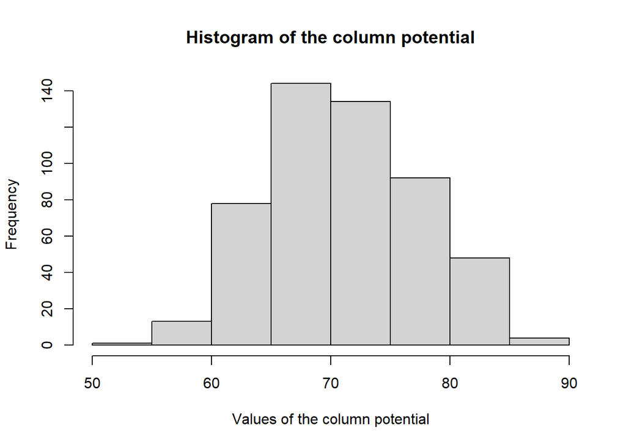

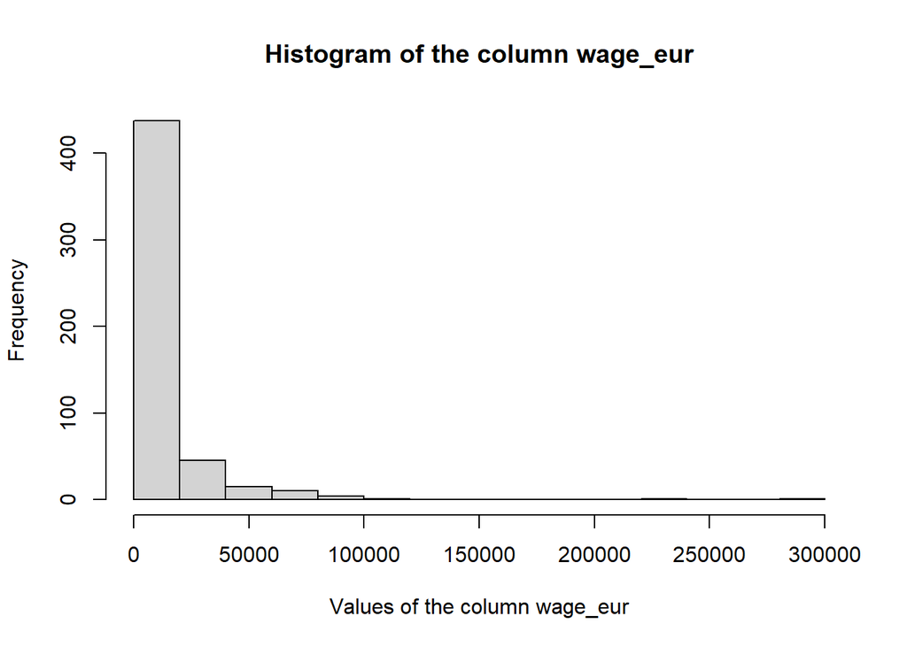

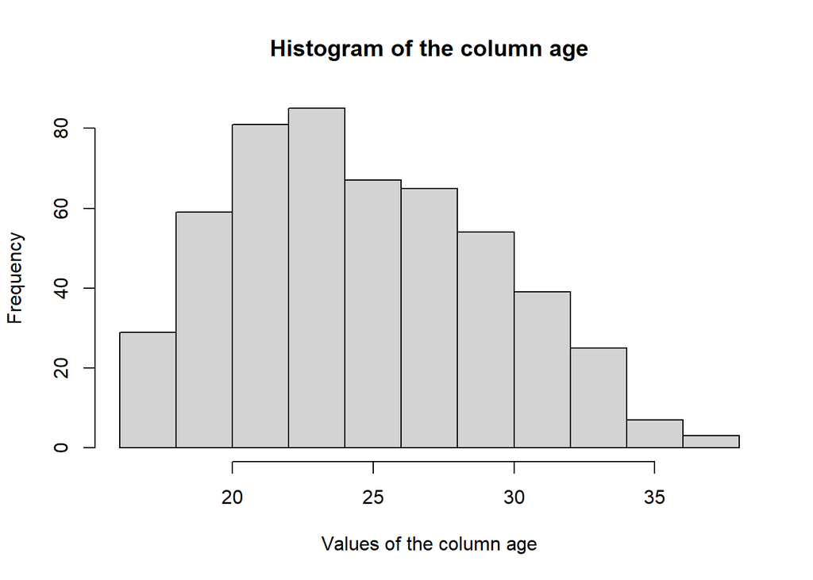

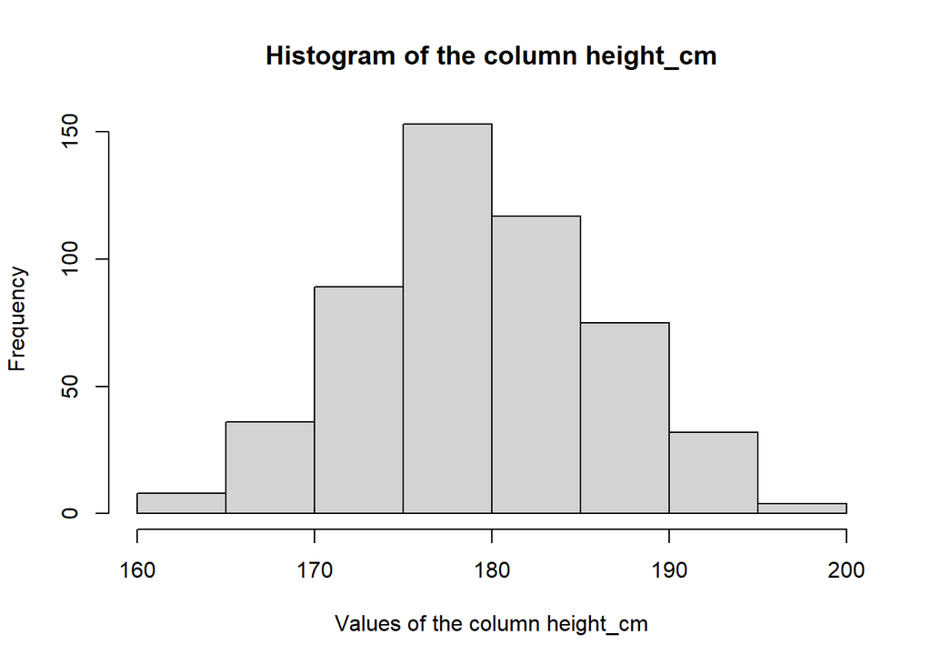

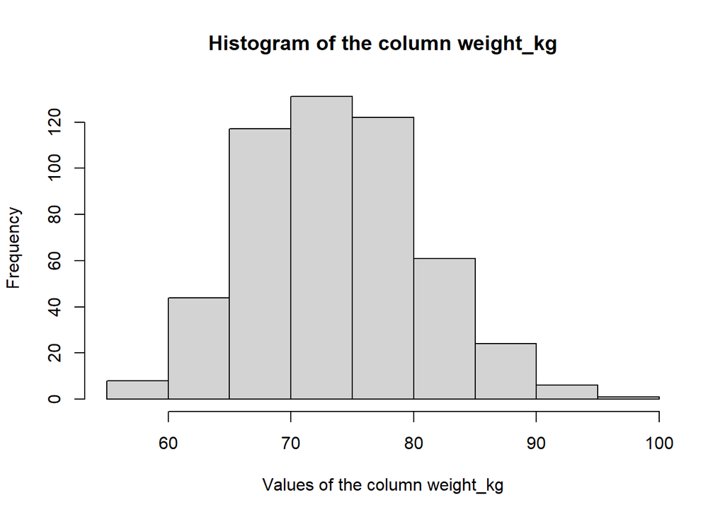

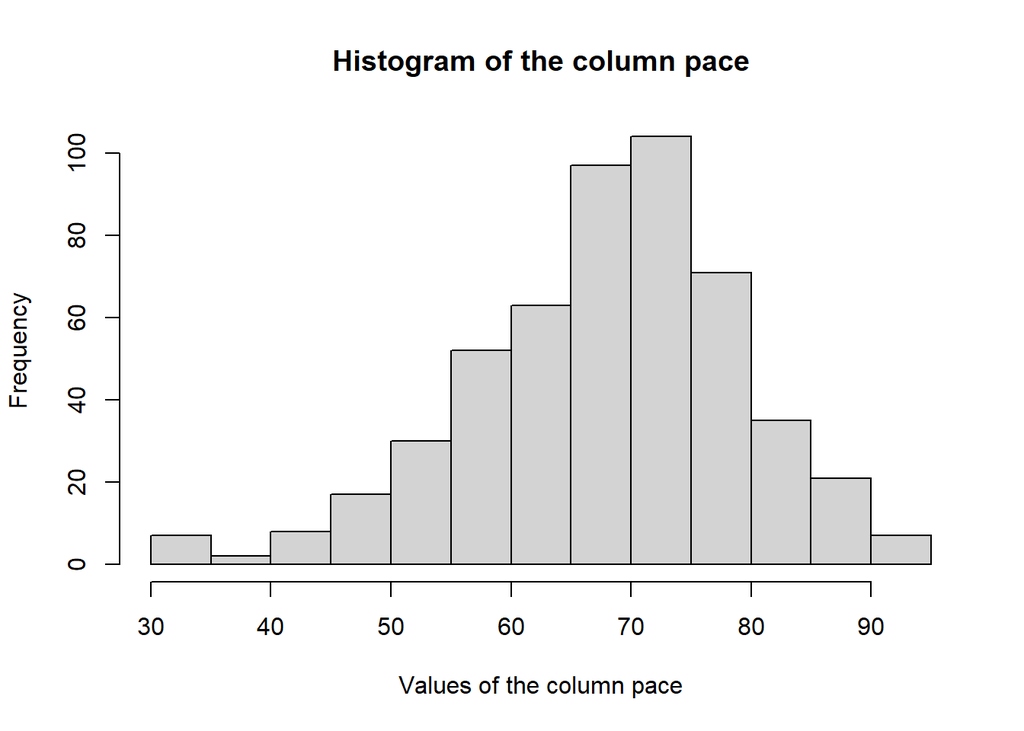

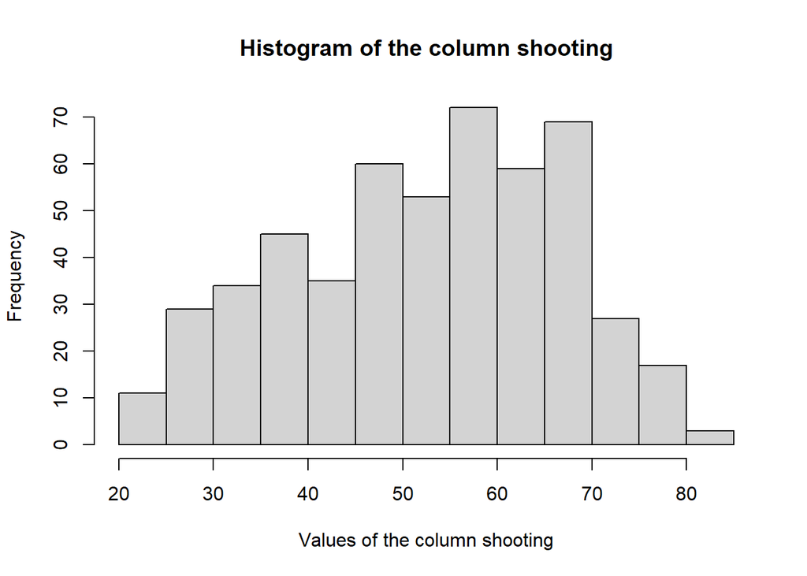

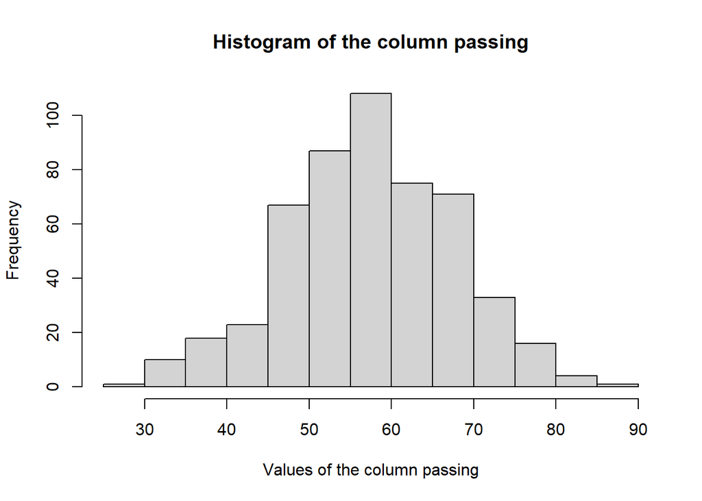

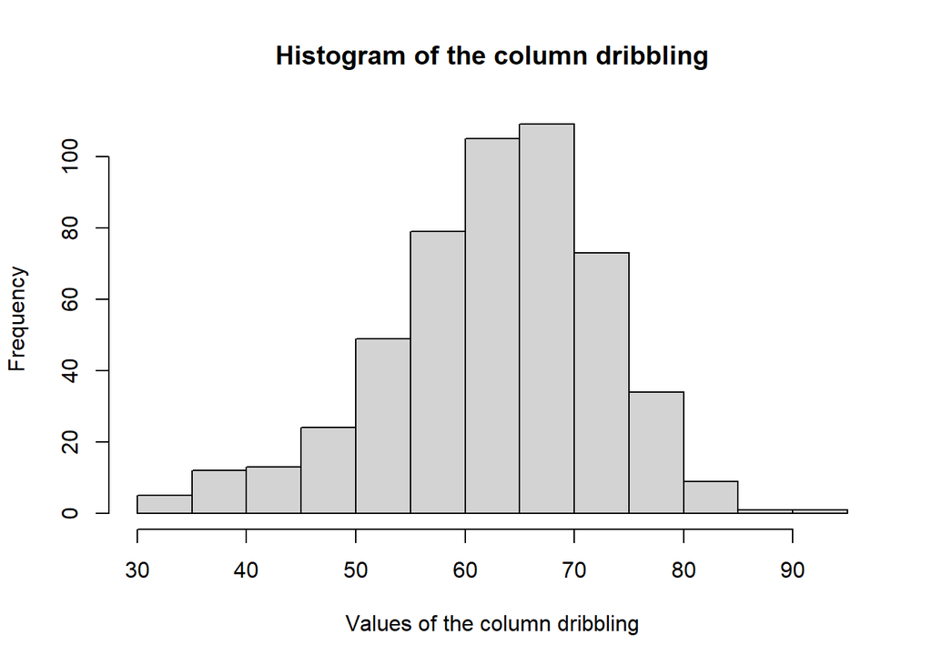

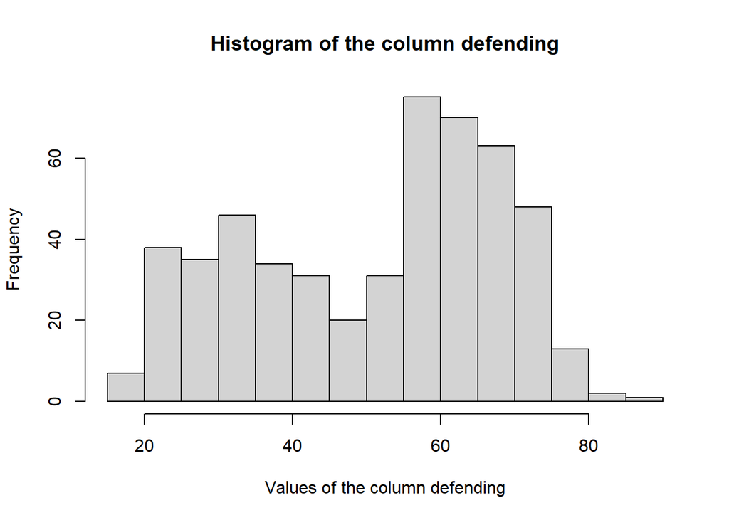

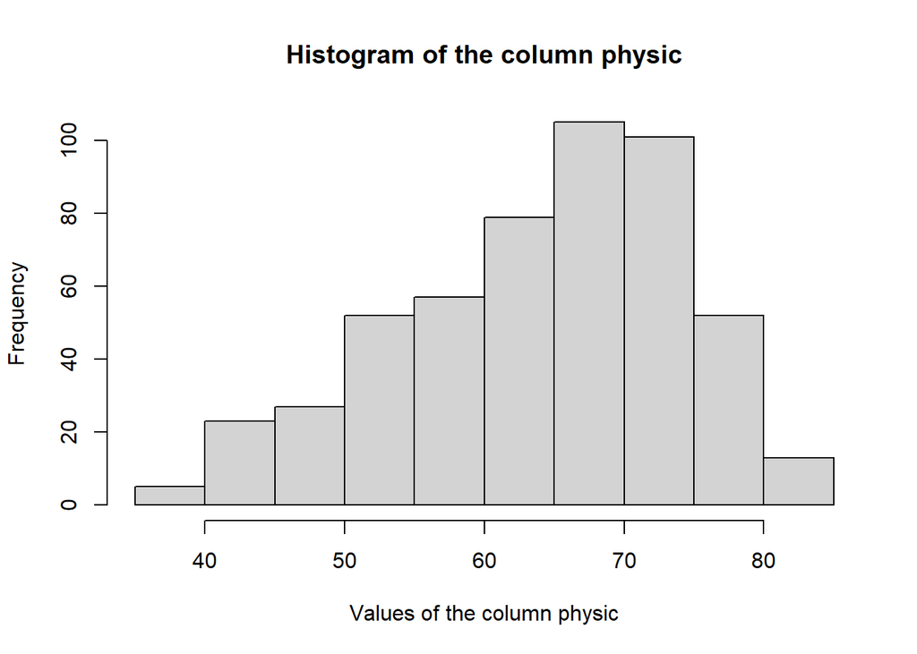

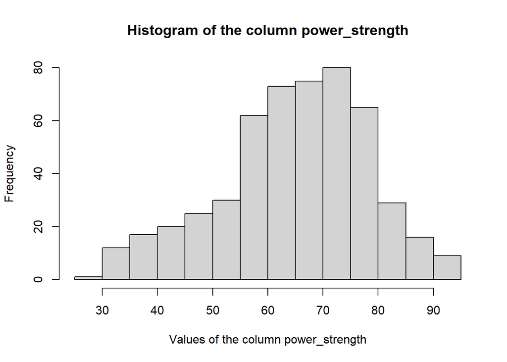

[1 more figures not shown]

```r
for (col in numeric_columns){
  title = paste("Histogram of the column", col)
  x_axis = paste("Values of the column", col)
  hist(df[,col], main=title, xlab=x_axis)
}
```

- `potential` column seems to follow a normal distribution.
- `wage_eur` column seems to follow logarithmic distribution. [5]
- `age` column seems to be slightly skewed to the right.
- `height_cm` column seems to be to follow a normal distribution.
- `weight_kg` column seems to be slightly skewed to the right.
- `pace` column seems to be skewed to the left.
- `shooting` column seems to be skewed to the left.
- `passing` column seems to follow a normal distribution.
- `dribbling` column seems to be slightly skewed to the left.
- `defending` column seems to have 2 picks.
- `physic` column seems to be skewed to the left.
- `power_strength` column seems to be slightly skewed to the left.
- `power_long_shots` column seems to be skewed to the left.

Since the column `wage_eur` seems to follow a logarithmic distribution, I will use a log function to transform values so that it tryies to follow now a normal distribution.

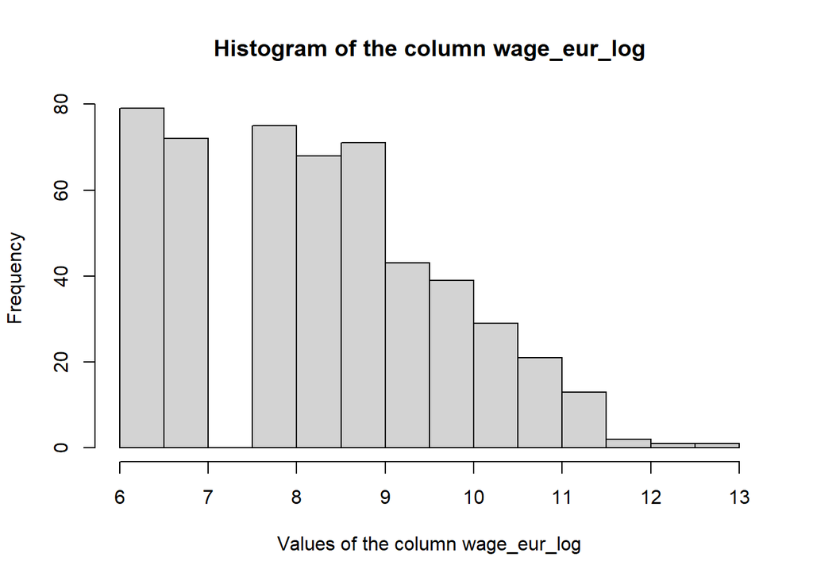

```r
df$wage_eur_log <- log(df$wage_eur)
hist(df$wage_eur_log, main="Histogram of the column wage_eur_log", xlab="Values of the column wage_eur_log")
```

- `wage_eur_log` seems to be skewed to the right.

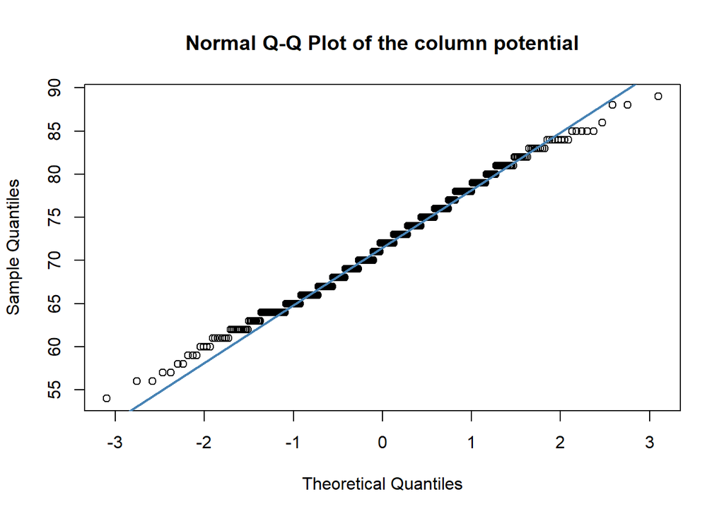

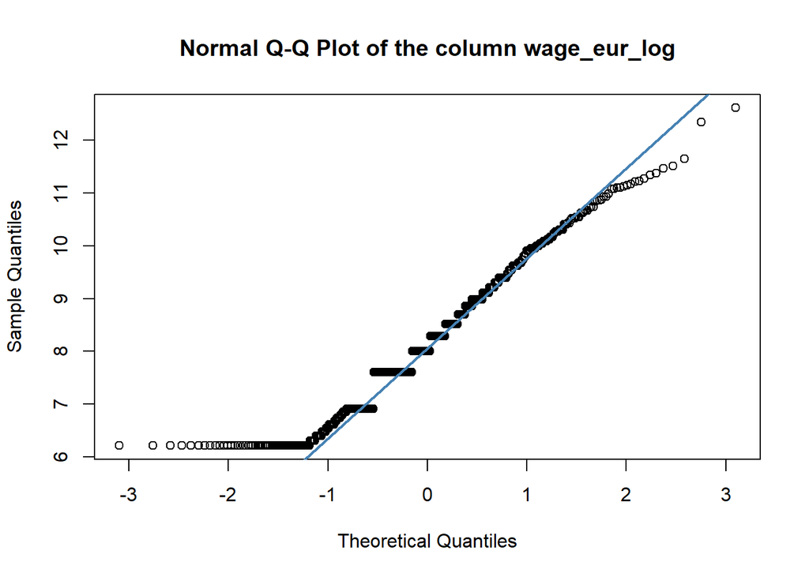

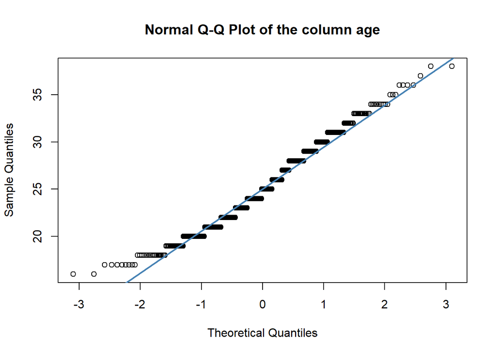

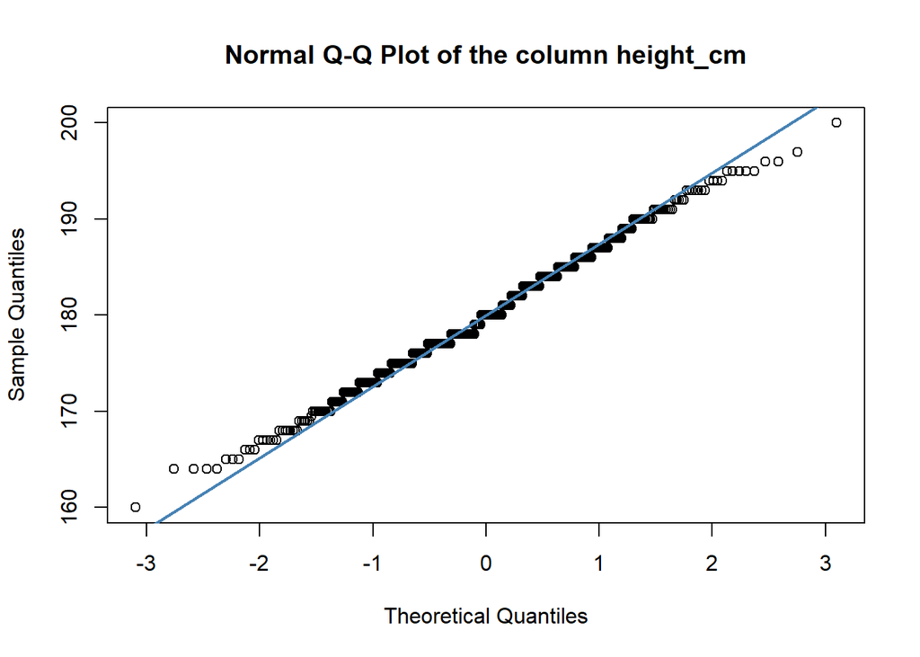

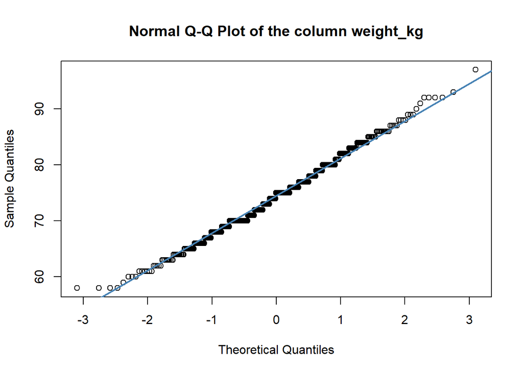

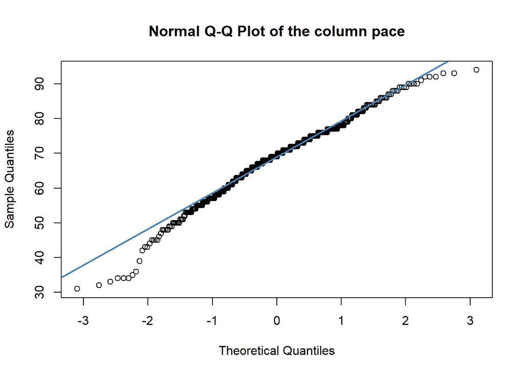

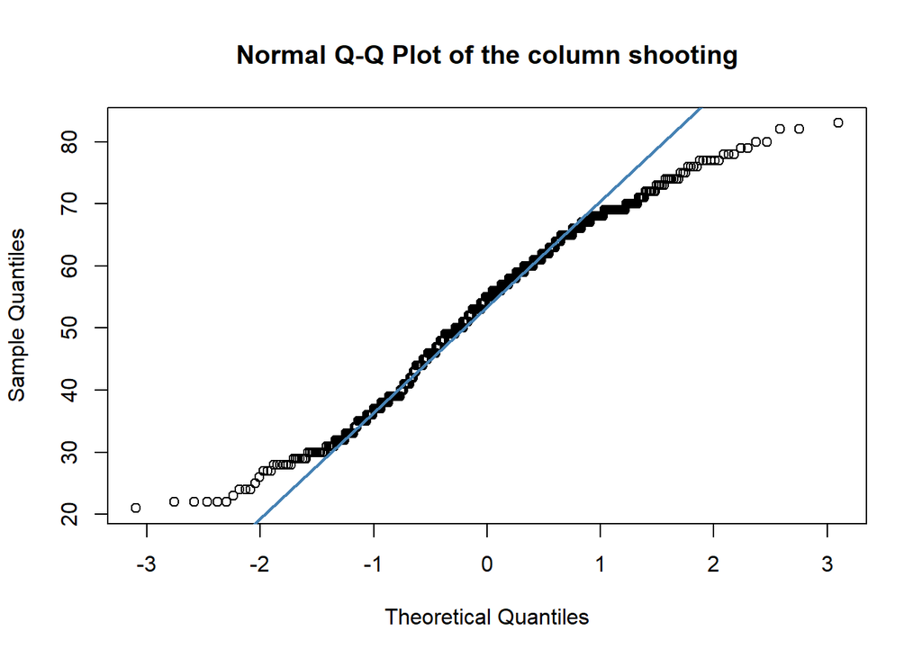

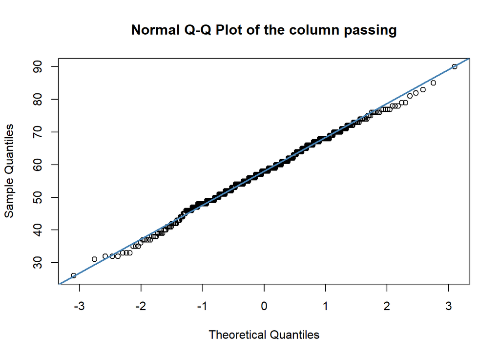

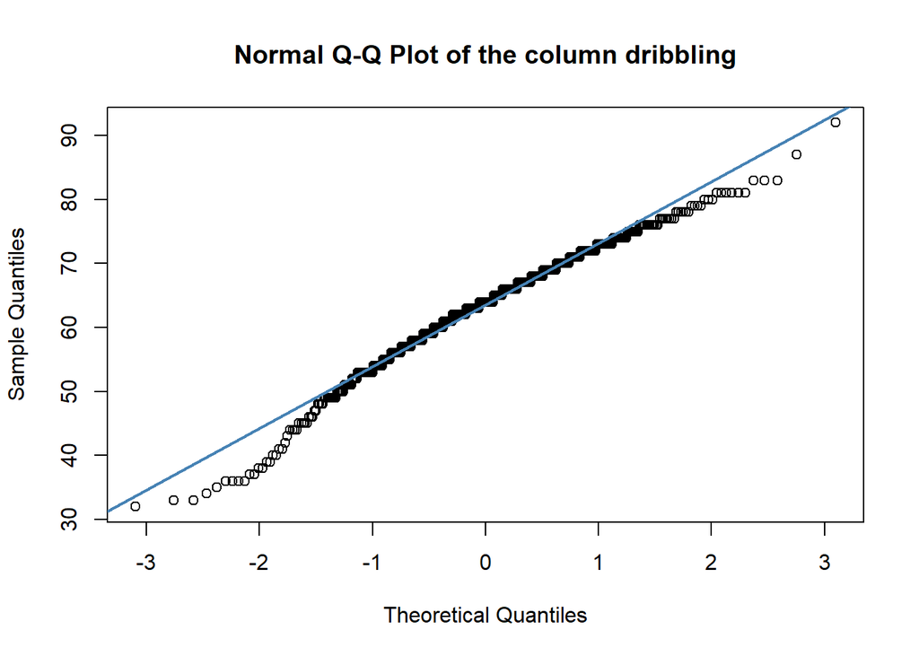

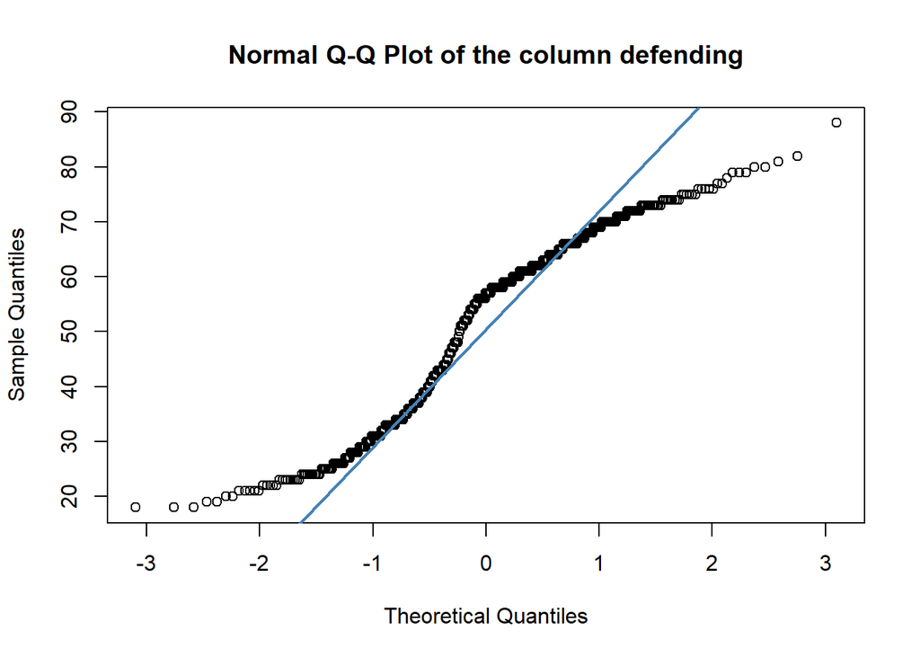

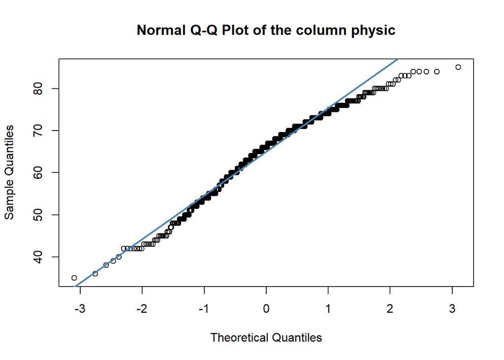

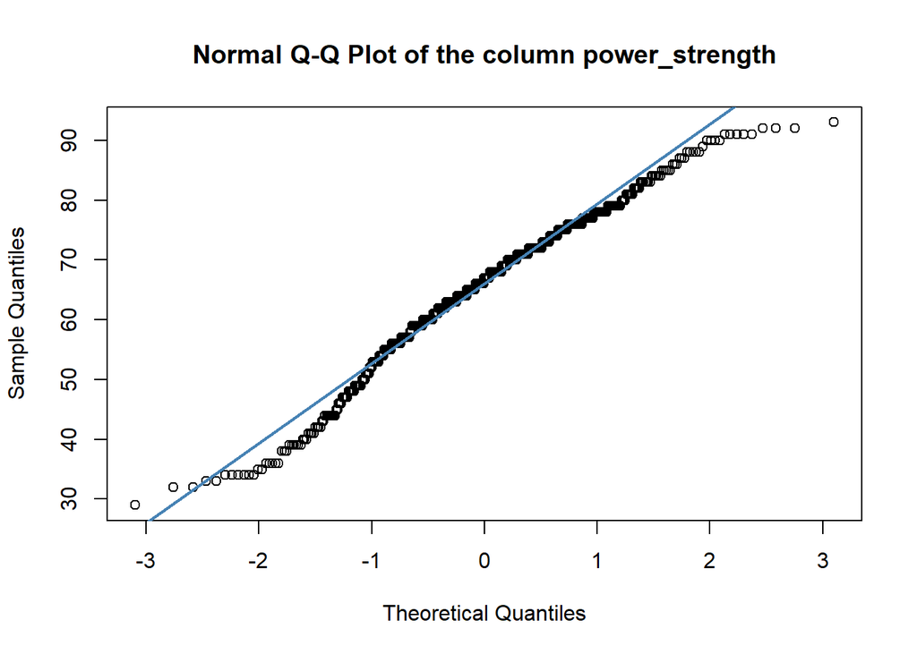

[1 more figures not shown]

```r
numeric_columns <- c("potential",
                     "wage_eur_log",
                     "age",
                     "height_cm",
                     "weight_kg",
                     "pace",
                     "shooting",
                     "passing",
                     "dribbling",
                     "defending",
                     "physic",
                     "power_strength",
                     "power_long_shots")

for (col in numeric_columns){
  title = paste("Normal Q-Q Plot of the column", col)
  qqnorm(df[,col], main=title)
  qqline(df[,col], col="steelblue", lwd=2)
}
```

```r
for (col in numeric_columns){
  message = paste("Shapiro-Wilk normality test for the column", col)
  print(message)
  shapiro_test <- shapiro.test(df[,col])
  print(shapiro_test[2])
  if (shapiro_test[2] < 0.05){
    shap_message <- paste("This is a very small p-value, we reject the null hypothesis that", col, "in this sample is normally distributed")
    print(shap_message)
  }
  else{
    print(paste("We failed to reject the null hypothesis. Column", col, "is normally distributed"))
  }
  cat("-------------------------------------------------------------------------------------------\n\n\n")
}
```

```
## [1] "Shapiro-Wilk normality test for the column potential"
## $p.value
## [1] 0.006241612
##
## [1] "This is a very small p-value, we reject the null hypothesis that potential in this sample is normally distributed"
## -------------------------------------------------------------------------------------------
##
##
## [1] "Shapiro-Wilk normality test for the column wage_eur_log"
## $p.value
## [1] 0.00000000002264849
##
## [1] "This is a very small p-value, we reject the null hypothesis that wage_eur_log in this sample is normally distributed"
## -------------------------------------------------------------------------------------------
##
##
## [1] "Shapiro-Wilk normality test for the column age"
## $p.value
## [1] 0.0000002278677
##
## [1] "This is a very small p-value, we reject the null hypothesis that age in this sample is normally distributed"
## -------------------------------------------------------------------------------------------
##
##
## [1] "Shapiro-Wilk normality test for the column height_cm"
## $p.value
## [1] 0.09240383
##
## [1] "We failed to reject the null hypothesis. Column height_cm is normally distributed"
## -------------------------------------------------------------------------------------------
##
##
## [1] "Shapiro-Wilk normality test for the column weight_kg"
## $p.value
## [1] 0.02663471
##
## [1] "This is a very small p-value, we reject the null hypothesis that weight_kg in this sample is normally distributed"
## -------------------------------------------------------------------------------------------
##
##
```

[output cut: 47 more lines]

```
##
## [1] "Shapiro-Wilk normality test for the column power_strength"
## $p.value
## [1] 0.0000006843208
##
## [1] "This is a very small p-value, we reject the null hypothesis that power_strength in this sample is normally distributed"
## -------------------------------------------------------------------------------------------
##
##
## [1] "Shapiro-Wilk normality test for the column power_long_shots"
## $p.value
## [1] 0.00000006352206
##
## [1] "This is a very small p-value, we reject the null hypothesis that power_long_shots in this sample is normally distributed"
## -------------------------------------------------------------------------------------------
```

After graphing the qq-plots and peforming shapiro tests, we can conclude the following:

- Columns `power_long_shots`, `power_strength`, `physic`, `physic`, `defending`, `dribbling`, `shooting`, `pace`, `weight_kg`, `age`, `wage_eur_log`, `potential` are not normally distributed.
- Columns `passing`, `height_cm` are normally distributed.